# Distribuição Normal Padrão 📊

## ✔️ Objetivos:

1. Compreender o conceito de Distribuição Normal Padrão.
2. Utilizar a Tabela Z para calcular probabilidades.
3. Transformar dados brutos em escores Z.
4. Visualizar graficamente a distribuição normal padrão.
5. Aplicar os conceitos na área da saúde 🏥.

## 😐 O que é Distribuição Normal Padrão?

A **Distribuição Normal Padrão** é uma distribuição normal com média 0 e desvio padrão 1. Ela é usada para padronizar variáveis e comparar diferentes conjuntos de dados.

Na área da saúde, podemos usar a distribuição normal padrão para analisar dados de exames laboratoriais, como níveis de glicose, colesterol e pressão arterial.

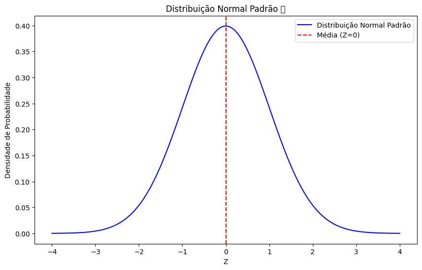

```python
# Código para plotagem da distribuição normal padrão
import numpy as np
import matplotlib.pyplot as plt
from scipy.stats import norm

# Parâmetros da distribuição normal padrão
mean = 0
std = 1

# Geração de valores Z
x = np.linspace(-4, 4, 1000)
y = norm.pdf(x, mean, std)

# Plotagem da distribuição normal padrão
plt.figure(figsize=(10, 6))
plt.plot(x, y, label='Distribuição Normal Padrão', color='blue')
plt.title('Distribuição Normal Padrão 📊')
plt.xlabel('Z')
plt.ylabel('Densidade de Probabilidade')
plt.axvline(x=0, color='red', linestyle='--', label='Média (Z=0)')
plt.legend()
plt.show()
```

## 🔄 Transformação de Dados para o Escore Z

A fórmula para calcular o escore Z é:

$Z = \frac{(X - \mu)}{\sigma}$

Onde:

- ( X ): Valor observado.
- ( \mu ): Média da população.
- ( \sigma ): Desvio padrão da população.

### Exemplo na Área da Saúde 🏥

Um hospital coletou dados sobre o nível de glicose em jejum de 1.000 pacientes. A média foi de 100 mg/dL, com um desvio padrão de 15 mg/dL. Qual é o escore Z para um paciente com glicose de 130 mg/dL?

```python
# Dados do exemplo
X = 130  # Nível de glicose do paciente
mu = 100  # Média da população
sigma = 15  # Desvio padrão

# Cálculo do escore Z
Z = (X - mu) / sigma
print(f"Escore Z para glicose de 130 mg/dL: {Z:.2f}")
```

```
Escore Z para glicose de 130 mg/dL: 2.00
```

## 📝 Uso da Tabela Z

As tabelas padronizadas foram criadas para facilitar a obtenção dos valores das áreas sob a curva normal e eliminar a necessidade de solucionar integrais definidas.

Para consultarmos os valores em uma tabela padronizada basta transformarmos nossa variável em uma variável padronizada $Z$.

Esta variável $Z$ representa o afastamento em desvios padrões de um valor da variável original em relação à média.

```python
import pandas as pd
import numpy as np
from scipy.stats import norm

tabela_normal_padronizada = pd.DataFrame(
    [],
    index=["{0:0.2f}".format(i / 100) for i in range(0, 400, 10)],
    columns = ["{0:0.2f}".format(i / 100) for i in range(0, 10)])

for index in tabela_normal_padronizada.index:
    for column in tabela_normal_padronizada.columns:
        Z = np.round(float(index) + float(column), 2)
        tabela_normal_padronizada.loc[index, column] = "{0:0.4f}".format(norm.cdf(Z))

tabela_normal_padronizada.rename_axis('Z', axis = 'columns', inplace = True)

tabela_normal_padronizada
```

| Z | 0.00 | 0.01 | 0.02 | 0.03 | 0.04 | 0.05 | 0.06 | 0.07 | 0.08 | 0.09 |
| --- | --- | --- | --- | --- | --- | --- | --- | --- | --- | --- |
| 0.00 | 0.5000 | 0.5040 | 0.5080 | 0.5120 | 0.5160 | 0.5199 | 0.5239 | 0.5279 | 0.5319 | 0.5359 |
| 0.10 | 0.5398 | 0.5438 | 0.5478 | 0.5517 | 0.5557 | 0.5596 | 0.5636 | 0.5675 | 0.5714 | 0.5753 |
| 0.20 | 0.5793 | 0.5832 | 0.5871 | 0.5910 | 0.5948 | 0.5987 | 0.6026 | 0.6064 | 0.6103 | 0.6141 |
| 0.30 | 0.6179 | 0.6217 | 0.6255 | 0.6293 | 0.6331 | 0.6368 | 0.6406 | 0.6443 | 0.6480 | 0.6517 |
| 0.40 | 0.6554 | 0.6591 | 0.6628 | 0.6664 | 0.6700 | 0.6736 | 0.6772 | 0.6808 | 0.6844 | 0.6879 |
| 0.50 | 0.6915 | 0.6950 | 0.6985 | 0.7019 | 0.7054 | 0.7088 | 0.7123 | 0.7157 | 0.7190 | 0.7224 |
| 0.60 | 0.7257 | 0.7291 | 0.7324 | 0.7357 | 0.7389 | 0.7422 | 0.7454 | 0.7486 | 0.7517 | 0.7549 |
| 0.70 | 0.7580 | 0.7611 | 0.7642 | 0.7673 | 0.7704 | 0.7734 | 0.7764 | 0.7794 | 0.7823 | 0.7852 |
| 0.80 | 0.7881 | 0.7910 | 0.7939 | 0.7967 | 0.7995 | 0.8023 | 0.8051 | 0.8078 | 0.8106 | 0.8133 |
| 0.90 | 0.8159 | 0.8186 | 0.8212 | 0.8238 | 0.8264 | 0.8289 | 0.8315 | 0.8340 | 0.8365 | 0.8389 |
| 1.00 | 0.8413 | 0.8438 | 0.8461 | 0.8485 | 0.8508 | 0.8531 | 0.8554 | 0.8577 | 0.8599 | 0.8621 |
| 1.10 | 0.8643 | 0.8665 | 0.8686 | 0.8708 | 0.8729 | 0.8749 | 0.8770 | 0.8790 | 0.8810 | 0.8830 |
| 1.20 | 0.8849 | 0.8869 | 0.8888 | 0.8907 | 0.8925 | 0.8944 | 0.8962 | 0.8980 | 0.8997 | 0.9015 |
| 1.30 | 0.9032 | 0.9049 | 0.9066 | 0.9082 | 0.9099 | 0.9115 | 0.9131 | 0.9147 | 0.9162 | 0.9177 |
| 1.40 | 0.9192 | 0.9207 | 0.9222 | 0.9236 | 0.9251 | 0.9265 | 0.9279 | 0.9292 | 0.9306 | 0.9319 |
| 1.50 | 0.9332 | 0.9345 | 0.9357 | 0.9370 | 0.9382 | 0.9394 | 0.9406 | 0.9418 | 0.9429 | 0.9441 |
| 1.60 | 0.9452 | 0.9463 | 0.9474 | 0.9484 | 0.9495 | 0.9505 | 0.9515 | 0.9525 | 0.9535 | 0.9545 |
| 1.70 | 0.9554 | 0.9564 | 0.9573 | 0.9582 | 0.9591 | 0.9599 | 0.9608 | 0.9616 | 0.9625 | 0.9633 |
| 1.80 | 0.9641 | 0.9649 | 0.9656 | 0.9664 | 0.9671 | 0.9678 | 0.9686 | 0.9693 | 0.9699 | 0.9706 |
| 1.90 | 0.9713 | 0.9719 | 0.9726 | 0.9732 | 0.9738 | 0.9744 | 0.9750 | 0.9756 | 0.9761 | 0.9767 |
| 2.00 | 0.9772 | 0.9778 | 0.9783 | 0.9788 | 0.9793 | 0.9798 | 0.9803 | 0.9808 | 0.9812 | 0.9817 |
| 2.10 | 0.9821 | 0.9826 | 0.9830 | 0.9834 | 0.9838 | 0.9842 | 0.9846 | 0.9850 | 0.9854 | 0.9857 |
| 2.20 | 0.9861 | 0.9864 | 0.9868 | 0.9871 | 0.9875 | 0.9878 | 0.9881 | 0.9884 | 0.9887 | 0.9890 |
| 2.30 | 0.9893 | 0.9896 | 0.9898 | 0.9901 | 0.9904 | 0.9906 | 0.9909 | 0.9911 | 0.9913 | 0.9916 |
| 2.40 | 0.9918 | 0.9920 | 0.9922 | 0.9925 | 0.9927 | 0.9929 | 0.9931 | 0.9932 | 0.9934 | 0.9936 |
| 2.50 | 0.9938 | 0.9940 | 0.9941 | 0.9943 | 0.9945 | 0.9946 | 0.9948 | 0.9949 | 0.9951 | 0.9952 |
| 2.60 | 0.9953 | 0.9955 | 0.9956 | 0.9957 | 0.9959 | 0.9960 | 0.9961 | 0.9962 | 0.9963 | 0.9964 |
| 2.70 | 0.9965 | 0.9966 | 0.9967 | 0.9968 | 0.9969 | 0.9970 | 0.9971 | 0.9972 | 0.9973 | 0.9974 |
| 2.80 | 0.9974 | 0.9975 | 0.9976 | 0.9977 | 0.9977 | 0.9978 | 0.9979 | 0.9979 | 0.9980 | 0.9981 |
| 2.90 | 0.9981 | 0.9982 | 0.9982 | 0.9983 | 0.9984 | 0.9984 | 0.9985 | 0.9985 | 0.9986 | 0.9986 |
| 3.00 | 0.9987 | 0.9987 | 0.9987 | 0.9988 | 0.9988 | 0.9989 | 0.9989 | 0.9989 | 0.9990 | 0.9990 |
| 3.10 | 0.9990 | 0.9991 | 0.9991 | 0.9991 | 0.9992 | 0.9992 | 0.9992 | 0.9992 | 0.9993 | 0.9993 |
| 3.20 | 0.9993 | 0.9993 | 0.9994 | 0.9994 | 0.9994 | 0.9994 | 0.9994 | 0.9995 | 0.9995 | 0.9995 |
| 3.30 | 0.9995 | 0.9995 | 0.9995 | 0.9996 | 0.9996 | 0.9996 | 0.9996 | 0.9996 | 0.9996 | 0.9997 |
| 3.40 | 0.9997 | 0.9997 | 0.9997 | 0.9997 | 0.9997 | 0.9997 | 0.9997 | 0.9997 | 0.9997 | 0.9998 |
| 3.50 | 0.9998 | 0.9998 | 0.9998 | 0.9998 | 0.9998 | 0.9998 | 0.9998 | 0.9998 | 0.9998 | 0.9998 |
| 3.60 | 0.9998 | 0.9998 | 0.9999 | 0.9999 | 0.9999 | 0.9999 | 0.9999 | 0.9999 | 0.9999 | 0.9999 |
| 3.70 | 0.9999 | 0.9999 | 0.9999 | 0.9999 | 0.9999 | 0.9999 | 0.9999 | 0.9999 | 0.9999 | 0.9999 |
| 3.80 | 0.9999 | 0.9999 | 0.9999 | 0.9999 | 0.9999 | 0.9999 | 0.9999 | 0.9999 | 0.9999 | 0.9999 |
| 3.90 | 1.0000 | 1.0000 | 1.0000 | 1.0000 | 1.0000 | 1.0000 | 1.0000 | 1.0000 | 1.0000 | 1.0000 |

[figure not shown]

A Tabela Z mostra a área acumulada à esquerda de um valor Z específico na distribuição normal padrão. Isso significa que a área representada na tabela é a probabilidade acumulada de encontrar um valor menor ou igual ao valor de Z.

A tabela acima fornece a área sob a curva entre −∞ e Z desvios padrão acima da média. Lembrando que por se tratar de valores padronizados temos μ=0 .

Cada valor da tabela representa a probabilidade acumulada para um determinado escore Z. A probabilidade indica a área sob a curva normal padrão à esquerda do valor Z. Portanto, ao usar a tabela, você está sempre respondendo à pergunta: "Qual a probabilidade de obter um valor menor ou igual a Z?"

Além disso, um conceito fundamental ligado à tabela Z é o percentil. O percentil indica a posição relativa de um valor dentro de um conjunto de dados, mostrando quanto da distribuição está abaixo daquele valor.

O valor Z = 1,28 corresponde a um percentil de aproximadamente 90 (ou 89,97% para ser exato). Isso significa que 90% da população tem valores menores ou iguais ao valor associado ao escore Z de 1,28. Em termos de saúde, se o nível de colesterol de um paciente está no percentil 90, ele tem um nível de colesterol maior que 90% da população.

Ou seja, a tabela Z nos permite não apenas calcular probabilidades, mas também entender como um valor se posiciona em relação à população inteira. Isso é fundamental para interpretações estatísticas e comparações na prática clínica e epidemiológica. 💡

#### **Exemplo 1:**

Em um estudo sobre os níveis de colesterol de uma população adulta, verificou-se que o conjunto de dados segue uma distribuição aproximadamente normal, com média de 200 mg/dL e desvio padrão de 20 mg/dL. Com estas informações, obtenha o seguinte conjunto de probabilidades:

- A. Probabilidade de um adulto selecionado ao acaso ter colesterol menor que 180 mg/dL.
- B. Probabilidade de um adulto selecionado ao acaso ter colesterol entre 180 mg/dL e 220 mg/dL.
- C. Probabilidade de um adulto selecionado ao acaso ter colesterol maior que 240 mg/dL.

```python
from scipy.stats import norm

# Parâmetros da distribuição normal
media = 200  # Média de colesterol (mg/dL)
desvio_padrao = 20  # Desvio padrão (mg/dL)
```

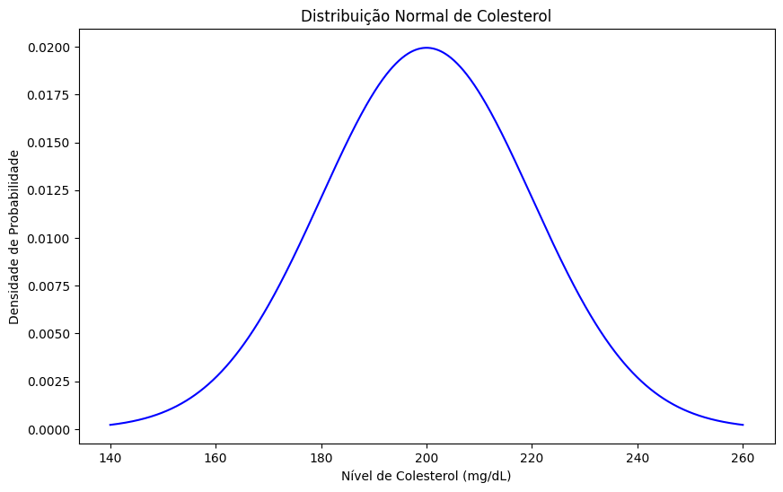

```python
# Plotando a distribuição normal com as áreas destacadas

# Valores para o eixo X
x = np.linspace(140, 260, 1000)
y = norm.pdf(x, media, desvio_padrao)

# Gráfico
plt.figure(figsize=(10, 6))
plt.plot(x, y, label='Distribuição Normal de Colesterol', color='blue')
plt.title('Distribuição Normal de Colesterol')
plt.xlabel('Nível de Colesterol (mg/dL)')
plt.ylabel('Densidade de Probabilidade')
```

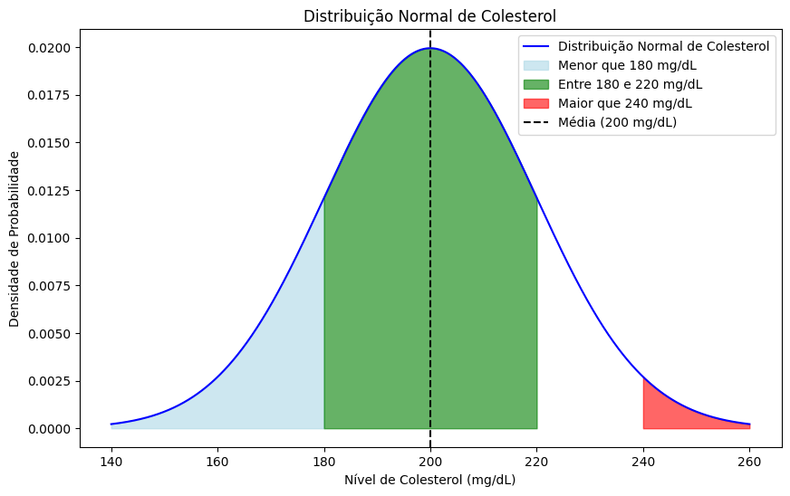

```python
# Importando as bibliotecas necessárias
import numpy as np
import matplotlib.pyplot as plt
from scipy.stats import norm

# Parâmetros da distribuição normal
media = 200  # Média de colesterol (mg/dL)
desvio_padrao = 20  # Desvio padrão (mg/dL)

# Valores para o eixo X
x = np.linspace(140, 260, 1000)
y = norm.pdf(x, media, desvio_padrao)

# Gráfico
plt.figure(figsize=(10, 6))
plt.plot(x, y, label='Distribuição Normal de Colesterol', color='blue')
plt.title('Distribuição Normal de Colesterol')
plt.xlabel('Nível de Colesterol (mg/dL)')
plt.ylabel('Densidade de Probabilidade')

# Área A: Colesterol menor que 180 mg/dL
x_a = np.linspace(140, 180, 300)
y_a = norm.pdf(x_a, media, desvio_padrao)
plt.fill_between(x_a, y_a, color='lightblue', alpha=0.6, label='Menor que 180 mg/dL')

# Área B: Colesterol entre 180 mg/dL e 220 mg/dL
x_b = np.linspace(180, 220, 300)
y_b = norm.pdf(x_b, media, desvio_padrao)
plt.fill_between(x_b, y_b, color='green', alpha=0.6, label='Entre 180 e 220 mg/dL')

# Área C: Colesterol maior que 240 mg/dL
x_c = np.linspace(240, 260, 100)
y_c = norm.pdf(x_c, media, desvio_padrao)
plt.fill_between(x_c, y_c, color='red', alpha=0.6, label='Maior que 240 mg/dL')

# Linha da média
plt.axvline(media, color='black', linestyle='--', label='Média (200 mg/dL)')

# Legenda
plt.legend()
plt.show()
```

##### Solução A

```python
# A. Probabilidade de ter colesterol menor que 180 mg/dL
z_a = (180 - media) / desvio_padrao
z_a
```

```
-1.0
```

A Tabela Z tradicional realmente mostra apenas os valores positivos de Z. Isso acontece porque a distribuição normal padrão é simétrica em torno da média (0).

Isso facilita a interpretação e evita a necessidade de tabelas negativas, já que podemos usar a simetria da distribuição normal.

```python
# Filtrar a tabela para Z = 1
tabela_z_igual_1 = tabela_normal_padronizada[tabela_normal_padronizada.index == '1.00']
tabela_z_igual_1
```

| Z | 0.00 | 0.01 | 0.02 | 0.03 | 0.04 | 0.05 | 0.06 | 0.07 | 0.08 | 0.09 |
| --- | --- | --- | --- | --- | --- | --- | --- | --- | --- | --- |
| 1.00 | 0.8413 | 0.8438 | 0.8461 | 0.8485 | 0.8508 | 0.8531 | 0.8554 | 0.8577 | 0.8599 | 0.8621 |

```python
tabela_z_igual_1 = tabela_normal_padronizada[tabela_normal_padronizada.index == '1.00']
valor_0_00 = tabela_z_igual_1['0.00'].values[0]
valor_0_00
```

```
'0.8413'
```

Ou usar a Função de Distribuição Cumulativa

```python
from scipy.stats import norm
norm.cdf(z)
```

[output not shown]

##### Solução B

```python
# B. Probabilidade de ter colesterol entre 180 mg/dL e 220 mg/dL
z_b1 = (180 - media) / desvio_padrao
z_b2 = (220 - media) / desvio_padrao
prob_b = norm.cdf(z_b2) - norm.cdf(z_b1)
```

```python
prob_b
```

```
np.float64(0.6826894921370859)
```

##### Solução C

```python
# C. Probabilidade de ter colesterol maior que 240 mg/dL
z_c = (240 - media) / desvio_padrao
prob_c = 1 - norm.cdf(z_c)
prob_c
```

```
np.float64(0.02275013194817921)
```

Ou usando a função SF

```python
from scipy.stats import norm

# Calcular a probabilidade acumulada para z_c
prob_neg = norm.sf(z_c)
print(f"Probabilidade acumulada para Z <= -1: {prob_neg * 100:.2f}%")
```

[output not shown]

#### **Exemplo 2:**

Um hospital realizou um estudo com 1.000 pacientes para analisar os níveis de colesterol total. A distribuição dos valores de colesterol seguiu uma distribuição normal com:

Média ( 𝜇 μ) = 200 mg/dL

Desvio padrão ( 𝜎 σ) = 20 mg/dL

Pergunta: Qual é o nível de colesterol que corresponde ao percentil 90?

O que significa estar no percentil 90 nesse contexto?

```python
# Parâmetros da distribuição normal
mu = 200  # Média de colesterol (mg/dL)
sigma = 20  # Desvio padrão (mg/dL)
```

Para encontrar o nível de colesterol associado ao percentil 90, precisamos identificar o valor de Z que corresponde a uma probabilidade acumulada de 0,90.

Consultando a Tabela Z

```python
# Valor Z para o percentil 90
z_percentil_90 = 1.28
```

Ou utilizando funções python

```python
# Probabilidade acumulada para o percentil 90
probabilidade = 0.90

# Usando a função ppf para encontrar o valor de Z
z_percentil_90 = norm.ppf(probabilidade)

print(f"Valor de Z para o percentil 90: {z_percentil_90:.2f}")
```

```
Valor de Z para o percentil 90: 1.28
```

- A função ppf significa Percent Point Function e retorna o valor Z cujo valor acumulado da distribuição normal é igual à probabilidade fornecida.

Agora podemos reconverter o valor Z para a normal não padrão

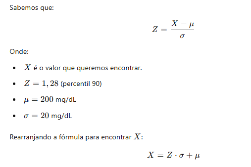

```python
# Calculando o valor de colesterol correspondente ao percentil 90
colesterol_90 = z_percentil_90 * sigma + mu

colesterol_90
```

```
np.float64(225.631031310892)
```

Estar no percentil 90 significa que 90% da população têm níveis de colesterol menores ou iguais a 225,6 mg/dL. Ou seja:

Apenas 10% dos pacientes têm colesterol maior que 225,6 mg/dL.

Na prática clínica, isso indica que um paciente com colesterol de 226 mg/dL ou mais está no topo dos valores elevados em relação à população estudada. Isso pode ser considerado um indicador de risco aumentado, dependendo dos parâmetros clínicos estabelecidos.

## 📝 Conclusão

A principal diferença entre usar o cdf diretamente com os dados não padronizados ou com os Z-scores está no contexto de aplicação e na facilidade de interpretação. Vamos detalhar isso:

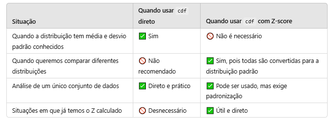

- Usando cdf com dados originais: A interpretação é direta: a probabilidade acumulada até o valor X dentro da distribuição normal específica. Exemplo: "Qual a probabilidade de um paciente ter colesterol menor que 220 mg/dL?"
- Usando cdf com Z-score: A interpretação é baseada na distância da média em termos de desvios padrão. Exemplo: "Qual a probabilidade de um valor estar a 1 desvio padrão da média?"

A abordagem padronizada (Z-score) permite:

- Comparar diferentes conjuntos de dados com médias e desvios padrão distintos.
- Facilitar a análise estatística e a generalização dos resultados.
- A abordagem direta com cdf não oferece essa flexibilidade, pois os resultados são específicos para uma distribuição com parâmetros definidos.

💡 Exemplo Prático: Comparação de Altura e Colesterol

- Altura: Média 1,70 m e desvio padrão 0,1 m. Probabilidade de ter altura maior que 1,80 m.
- Colesterol: Média 200 mg/dL e desvio padrão 20 mg/dL. Probabilidade de ter colesterol maior que 240 mg/dL.

```python
from scipy.stats import norm

# Parâmetros da altura
media_altura = 1.70
desvio_padrao_altura = 0.1
altura = 1.80

# Parâmetros do colesterol
media_colesterol = 200
desvio_padrao_colesterol = 20
colesterol = 240

# Cálculo direto com cdf
prob_altura_direto = 1 - norm.cdf(altura, media_altura, desvio_padrao_altura)
prob_colesterol_direto = 1 - norm.cdf(colesterol, media_colesterol, desvio_padrao_colesterol)

# Cálculo usando Z-score
z_altura = (altura - media_altura) / desvio_padrao_altura
print(f"Z-score de altura > 1,80 m: {z_altura:.2f}")
z_colesterol = (colesterol - media_colesterol) / desvio_padrao_colesterol
print(f"Z-score de colesterol > 240 mg/dL: {z_colesterol:.2f}")

prob_altura_z = norm.sf(z_altura)  # Usando sf para a cauda direita
prob_colesterol_z = norm.sf(z_colesterol)  # Usando sf para a cauda direita

print(f"Probabilidade direta de altura > 1,80 m: {prob_altura_direto * 100:.2f}%")
print(f"Probabilidade direta de colesterol > 240 mg/dL: {prob_colesterol_direto * 100:.2f}%")

print(f"Probabilidade com Z-score de altura > 1,80 m: {prob_altura_z * 100:.2f}%")
print(f"Probabilidade com Z-score de colesterol > 240 mg/dL: {prob_colesterol_z * 100:.2f}%")
```

```
Z-score de altura > 1,80 m: 1.00
Z-score de colesterol > 240 mg/dL: 2.00
Probabilidade direta de altura > 1,80 m: 15.87%
Probabilidade direta de colesterol > 240 mg/dL: 2.28%
Probabilidade com Z-score de altura > 1,80 m: 15.87%
Probabilidade com Z-score de colesterol > 240 mg/dL: 2.28%
```

Usando os Z-scores, percebemos que: A altura de 1,80 m está a 1 desvio padrão acima da média. O colesterol de 240 mg/dL está a 2 desvios padrões acima da média. Portanto, níveis de colesterol acima de 240 mg/dL são muito mais raros do que alturas acima de 1,80 m.

No entanto, na prática, não há muita diferença entre usar o cdf diretamente com os dados originais ou usar com o Z-score, especialmente quando temos ferramentas de programação à disposição, como Python. Ambos os métodos chegam ao mesmo resultado, desde que os cálculos estejam corretos.

A grande vantagem da Tabela Z é justamente em situações onde não se tem acesso a um computador ou uma ferramenta de programação. Por exemplo:

- Cálculos à Mão ou com Calculadora Simples: A tabela fornece rapidamente a probabilidade acumulada para diferentes valores de Z, sem precisar fazer cálculos complexos.
- Materiais Didáticos e Provas: Em contextos acadêmicos ou provas, como em vestibulares ou exames estatísticos, a tabela Z é uma ferramenta prática e tradicional.
- Situações de Campo ou Sem Computador: Profissionais de saúde, estatísticos ou cientistas de dados podem usar a tabela quando estão longe de ferramentas computacionais.

Mas é importante lembrar que:

- A tabela Z facilita o entendimento conceitual sobre a normal padrão. Mesmo que não usemos tanto em programação, ela ainda é uma ferramenta valiosa para o aprendizado e para situações práticas sem computador.